# Visualizing Forest Fire Data

Uni Lee

12/4/2020

Forecasting forest fires is important to minimize environmental and economic damages. [Cortez and Morais](http://www3.dsi.uminho.pt/pcortez/fires.pdf) used a Data Mining approach to predict burned area of forest fires in Portugal.

In this exercise, we will perform an exploratory analysis of the forest fire dataset via visualization.

# Data

## Understanding the raw data structure

```r
# Load data from https://archive.ics.uci.edu/ml/machine-learning-databases/forest-fires/
fire_raw <- read.csv("data/3_forestfires.csv")
str(fire_raw)
```

```
## 'data.frame':    517 obs. of  13 variables:
##  $ X    : int  7 7 7 8 8 8 8 8 8 7 ...
##  $ Y    : int  5 4 4 6 6 6 6 6 6 5 ...
##  $ month: chr  "mar" "oct" "oct" "mar" ...
##  $ day  : chr  "fri" "tue" "sat" "fri" ...
##  $ FFMC : num  86.2 90.6 90.6 91.7 89.3 92.3 92.3 91.5 91 92.5 ...
##  $ DMC  : num  26.2 35.4 43.7 33.3 51.3 ...
##  $ DC   : num  94.3 669.1 686.9 77.5 102.2 ...
##  $ ISI  : num  5.1 6.7 6.7 9 9.6 14.7 8.5 10.7 7 7.1 ...
##  $ temp : num  8.2 18 14.6 8.3 11.4 22.2 24.1 8 13.1 22.8 ...
##  $ RH   : int  51 33 33 97 99 29 27 86 63 40 ...
##  $ wind : num  6.7 0.9 1.3 4 1.8 5.4 3.1 2.2 5.4 4 ...
##  $ rain : num  0 0 0 0.2 0 0 0 0 0 0 ...
##  $ area : num  0 0 0 0 0 0 0 0 0 0 ...
```

Each row represents a forest fire event. There are 13 variables that describe each event. Refer to the following description of each variable, taken from the codebook.

- X: X-axis spatial coordinate within the Montesinho park map (1 to 9)
- *Y*: Y-axis spatial coordinate within the Montesinho park map (2 to 9)
- *month*: Month of the year: ‘jan’ to ‘dec’
- *day*: Day of the week (‘mon’ to ‘sun’)
- *FFMC*: Fine Fuel Moisture Code index from the FWI system (18.7 to 96.20). This code is an indicator of the relative ease of ignition and the flammability of fine fuel.
- *DMC*: Duff Moisture Code index from the FWI system (1.1 to 291.3). It is a numeric rating of the average moisture content of loosely compacted organic layers of moderate depth. This code gives an indication of fuel consumption in moderate duff layers and medium-size woody material.
- *DC*: Drought Code index from the FWI system (7.9 to 860.6). This code is a useful indicator of seasonal drought effects on forest fuels and the amount of smoldering in deep duff layers and large logs.
- *ISI*: Initial Spread Index from the FWI system (0.0 to 56.10). It is a numeric rating of the expected rate of fire spread, calculated based on wind speed and FFMC.
- *temp*: Temperature in Celsius degrees (2.2 to 33.30)
- *RH*: Relative humidity in percentage: 15.0 to 100
- *wind*: Wind speed in km/h: 0.40 to 9.40
- *rain*: Outside rain in mm/m2 : 0.0 to 6.4
- *area*: The burned area of the forest (in ha): 0.00 to 1090.84

*The acronym FWI stands for “fire weather index”, a method used by scientists to quantify risk factors for forest fires. Read more [here](https://cwfis.cfs.nrcan.gc.ca/background/summary/fwi)*

## Prepping data for visualization

```r
# Convert the month and day into a categorical variable, making sure that the months and day are ordered correctly (rather than in alphabetical order).

fire <- fire_raw %>% mutate(
  month = factor(month, levels= c("jan", "feb", "mar", "apr", "may", "jun", "jul", "aug", "sep", "oct", "nov", "dec")),
  day = factor(day, levels = c("mon", "tue", "wed", "thu", "fri", "sat", "sun"))
)
```

# Visualization

## Which months and days of the week do forest fires happen the most?

During the months of August and September, forest fires occur the most frequently.

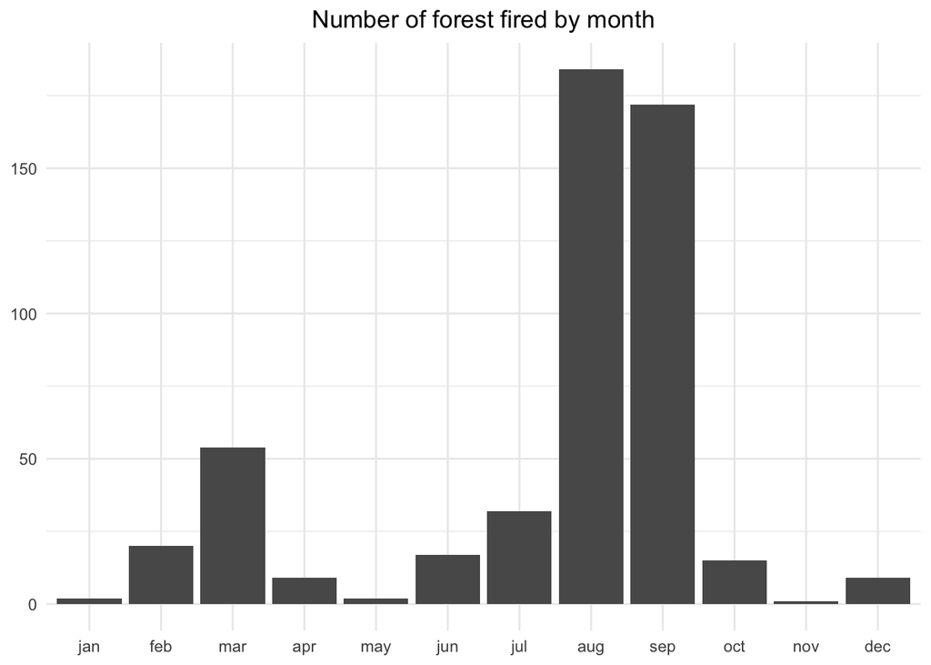

```r
# by month
count_month <- fire %>% group_by(month) %>%
  summarize(count = n()) %>% as_data_frame()

ggplot(count_month, aes(x=month, y=count)) +
  geom_col() +
  labs(title = "Number of forest fired by month") +
  theme_minimal() +
  theme(axis.title.x = element_blank(),
        axis.title.y = element_blank(),
        plot.title = element_text(hjust=0.5))
```

Forest fires are more likely to occur during weekends (fri-sun) than weekdays (mon-thu).

```r
# by day
count_day <- fire %>% group_by(day) %>%
  summarize(count = n())
```

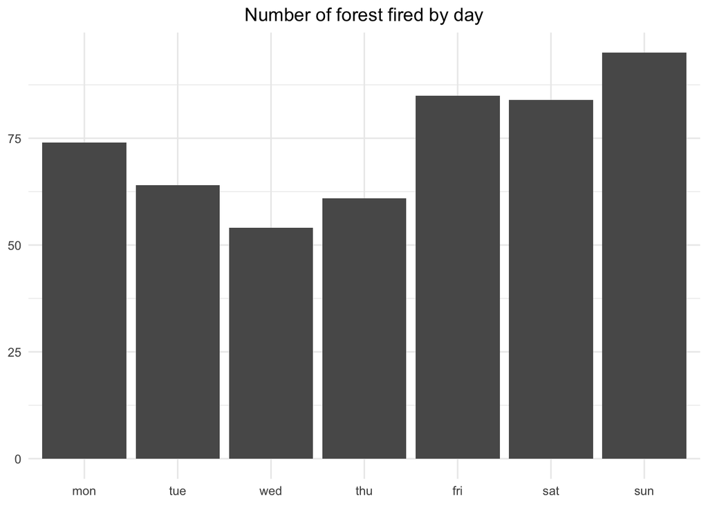

```r
ggplot(count_day, aes(x=day, y=count)) +
  geom_col() +
  labs(title = "Number of forest fired by day") +
  theme_minimal() +
  theme(axis.title.x = element_blank(),
        axis.title.y = element_blank(),
        plot.title = element_text(hjust=0.5))
```

## Examining time variance of other variables

During the months of Aug-Sept, the following variables exhibit high values, showing positive correlation with frequency of forest fires. * DC * DMC * Temperature

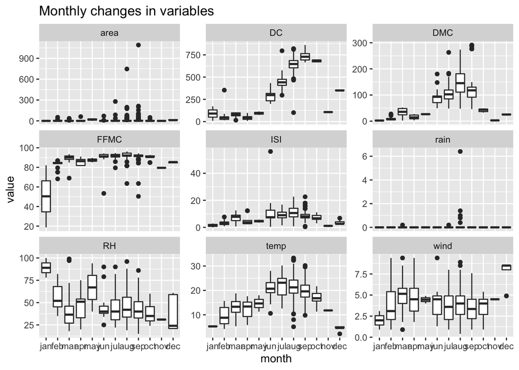

```r
# Turn the wide format into a long format
fire_long <- fire %>% pivot_longer(
  cols=c("FFMC", "DMC", "DC", "ISI", "temp", "RH", "wind", "rain", "area"),
  names_to = "var",
  values_to = "value"
)

# Graph it!
## We use boxplot here because there are many outliers.
ggplot(fire_long, aes(x=month, y=value)) +
  geom_boxplot() +
  facet_wrap(vars(var), scales="free_y") +
  labs(title = "Monthly changes in variables")
```

## Relationship between severity of forest fires and other variables

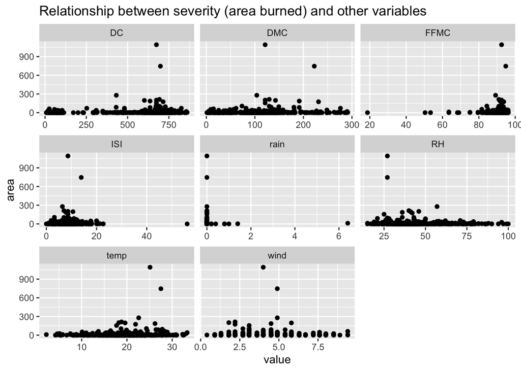

```r
fire_long_area <- fire %>% pivot_longer(
  cols=c("FFMC", "DMC", "DC", "ISI", "temp", "RH", "wind", "rain"),
  names_to = "var",
  values_to = "value"
)

ggplot(fire_long_area, aes(x=value, y=area)) +
  geom_point() +
  facet_wrap(vars(var), scales="free_x") +
  labs(title = "Relationship between severity (area burned) and other variables")
```

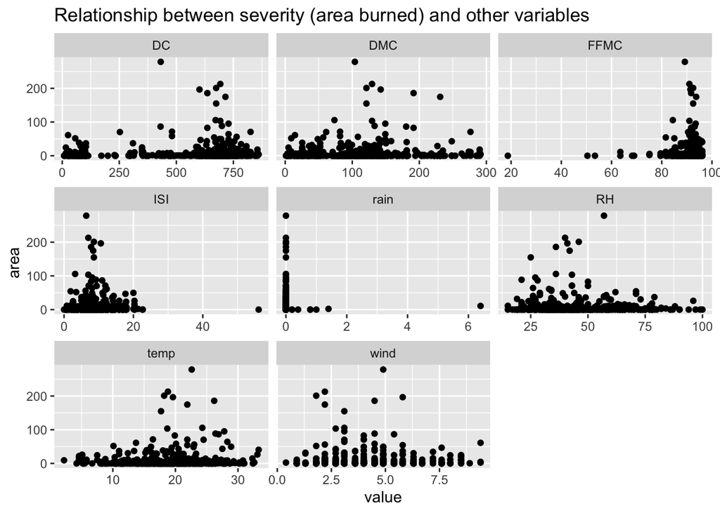

```r
# There are outliers in "area" variable that are distorting the visualization. To gain a more accurate understanding of the relationship, we will get rid of the outliers and graph again.

fire_long_area_outlier <- fire_long_area %>% filter(area<300)
ggplot(fire_long_area_outlier, aes(y=area, x=value)) +
  geom_point() +
  facet_wrap(vars(var), scales="free_x") +
  labs(title = "Relationship between severity (area burned) and other variables")
```

# Conclusion

Our exploratory data visualization has revealed that:

- DC (Drought Code Index) and temperature can be used as a predictor of both frequency and severity of forest fires.
- FFMC (Fine Fuel Moisture Code index) can be used as a predictor of severity of forest fires.
- DMC (Duff Moisture Code index) can be used as a predictor of frequency of forest fires.